# 2. Recipe

SangminJe

2021 4 25

## 개요

> 1. Recipe의 전반적인 개념에 대해서 설명합니다.
> 2. 본 문서는 tidymodels [공식 영문서](https://www.tidymodels.org/start/recipes/)를 참고로 만들었습니다.

## 목차

- 1. recipe란
- 2. Flight Data
- 3. Data Spliting
- 4. Recipe와 Role
- 5. Recipe 모델적합
- 6. 예측(Predicttion)
- 7. 모델평가(Evaluation)

## Recipe란

`Recipe`는 머신러닝 프로세스에서 **데이터의 전처리**를 도와주는 `tidymodel`의 전처리 패키지입니다. 아래와 같은 기능을 포함합니다. - Qualitative Variable(질적 변수)의 **dummy Variable(더미변수)** 로의 변환(질적 변수는 Categorucal Variable로 부르기도 합니다.) - **Feature Scaling** - 서로 다른 단위를 가지고 있는 데이터를 정규화해주는 과정 - 한 번에 모든 Variable을 변경 - **Key Feature**만 뽑아내기 - [참고자료](https://www.tidymodels.org/start/recipes/)

```r
library(tidymodels)      # 기본 패키지
# Helper packages
library(nycflights13)    # flight data를 위해 로드
library(skimr)           # 데이터 구조 살필 때 필요한 패키지
```

## Flight Data

flights 데이터는 뉴욕의 비행 출발/도착과 관련된 데이터입니다. 이 데이터를 통해서 어떤 비행기가 30분 연착할 지를 예측해보는 과정을 수행해보겠습니다.

먼저 데이터를 살펴봐야겠군요. 앞으로는 두 개의 테이블을 사용할 예정입니다.

```r
flights
```

```
## # A tibble: 336,776 x 19
##     year month   day dep_time sched_dep_time dep_delay arr_time sched_arr_time
##    <int> <int> <int>    <int>          <int>     <dbl>    <int>          <int>
##  1  2013     1     1      517            515         2      830            819
##  2  2013     1     1      533            529         4      850            830
##  3  2013     1     1      542            540         2      923            850
##  4  2013     1     1      544            545        -1     1004           1022
##  5  2013     1     1      554            600        -6      812            837
##  6  2013     1     1      554            558        -4      740            728
##  7  2013     1     1      555            600        -5      913            854
##  8  2013     1     1      557            600        -3      709            723
##  9  2013     1     1      557            600        -3      838            846
## 10  2013     1     1      558            600        -2      753            745
## # ... with 336,766 more rows, and 11 more variables: arr_delay <dbl>,
## #   carrier <chr>, flight <int>, tailnum <chr>, origin <chr>, dest <chr>,
## #   air_time <dbl>, distance <dbl>, hour <dbl>, minute <dbl>, time_hour <dttm>
```

```r
weather
```

```
## # A tibble: 26,115 x 15
##    origin  year month   day  hour  temp  dewp humid wind_dir wind_speed
##    <chr>  <int> <int> <int> <int> <dbl> <dbl> <dbl>    <dbl>      <dbl>
##  1 EWR     2013     1     1     1  39.0  26.1  59.4      270      10.4
##  2 EWR     2013     1     1     2  39.0  27.0  61.6      250       8.06
##  3 EWR     2013     1     1     3  39.0  28.0  64.4      240      11.5
##  4 EWR     2013     1     1     4  39.9  28.0  62.2      250      12.7
##  5 EWR     2013     1     1     5  39.0  28.0  64.4      260      12.7
##  6 EWR     2013     1     1     6  37.9  28.0  67.2      240      11.5
##  7 EWR     2013     1     1     7  39.0  28.0  64.4      240      15.0
##  8 EWR     2013     1     1     8  39.9  28.0  62.2      250      10.4
##  9 EWR     2013     1     1     9  39.9  28.0  62.2      260      15.0
## 10 EWR     2013     1     1    10  41    28.0  59.6      260      13.8
## # ... with 26,105 more rows, and 5 more variables: wind_gust <dbl>,
## #   precip <dbl>, pressure <dbl>, visib <dbl>, time_hour <dttm>
```

- weather 데이터는 날씨 데이터입니다. flights 데이터와는 `origin`과 `time_hour` 컬럼을 공유합니다.

##### 데이터 로드

데이터를 로드해보겠습니다.

```r
set.seed(123)

flight_data <-
  flights %>%
  # arr_delay라는 범주형 종속변수 만들기
  mutate(arr_delay = ifelse(arr_delay < 30,'on_time','late'),
         arr_delay = factor(arr_delay),
         # YYYY-MM-DD 데이터로 치환
         date = as.Date(time_hour)
       ) %>%
  # Weather Data와 Origin(출발지), time_hour(일자,시간) 을 키로 inner join 수행행
  inner_join(weather, by = c('origin','time_hour')) %>%
  # 필요한 컬럼만 가져오기
  select(dep_time, flight, origin, dest, air_time, distance,
         carrier, date, arr_delay, time_hour) %>%
  # Missing Data가 있는 열은 삭제
  na.omit() %>%
  mutate_if(is.character, as.factor)
```

그리고 연착된 비행기가 몇 퍼센트인지 살펴봅시다.

```r
flight_data %>%
  count(arr_delay) %>%
  mutate(prop = n/sum(n))
```

```
## # A tibble: 2 x 3
##   arr_delay      n  prop
## * <fct>      <int> <dbl>
## 1 late       52540 0.161
## 2 on_time   273279 0.839
```

#### 데이터 체크

- 우리는 비행기의 연착 여부를 종속변수로 하므로, **Logistic Regression**을 수행해야 함을 염두해둡시다.
- `skim`이라는 함수를 통해서 데이터의 구조를 편하게 파악할 수 있습니다.

```r
flight_data %>%
  skim(dest, carrier)
```

Data summary

| Name | Piped data |
| --- | --- |
| Number of rows | 325819 |
| Number of columns | 10 |
| _______________________ |  |
| Column type frequency: |  |
| factor | 2 |
| ________________________ |  |
| Group variables | None |

**Variable type: factor**

| skim_variable | n_missing | complete_rate | ordered | n_unique | top_counts |
| --- | --- | --- | --- | --- | --- |
| dest | 0 | 1 | FALSE | 104 | ATL: 16771, ORD: 16507, LAX: 15942, BOS: 14948 |
| carrier | 0 | 1 | FALSE | 16 | UA: 57489, B6: 53715, EV: 50868, DL: 47465 |

- **dest** 변수에는 약 **104**개의 값이 있는 것을 확인할 수 있습니다.
- 우리가 원하는 것은 **Logistic Regression**입니다. 따라서 해당 머신러닝을 수행하기 위해서는, **Nominal Variable**이 **Dummy Variable**로 치환되어야 합니다.
- 이후 분석 과정에서 치환 과정을 차차 다루겠습니다.

## Data Spliting

```r
# Random 결과를 Fixing
set.seed(123)
# 3/4를 트레이닝 데이터로 사용
data_split <- initial_split(flight_data, prop = 3/4)

# 트레이닝 셋과 테스트 셋으로 데이터 나누기
train_data <- training(data_split)
test_data <- testing(data_split)
```

- [`rsample`](https://rsample.tidymodels.org/)이라는 패키지를 통해서 Data Split을 진행할 수 있습니다.

## Recipe와 Role

```r
flights_rec <-
  # formula와 data를 정의하여 recipe 구축
  recipe(formula = arr_delay ~ ., data = train_data) %>%
  # role update
  update_role(flight, time_hour, new_role = "ID")
```

1. [`recipe`](https://recipes.tidymodels.org/reference/recipe.html)
- `formula`를 통해서 식을 정의해줍니다. 여기서 `.`은 모든 **predictor**를 의미합니다.
- `data`를 통해서 `train_data`를 지정합니다.
2. [`update_role`](https://recipes.tidymodels.org/reference/roles.html)
- `recipe`안에서 **role**을 부여하거나 바꿀 때 사용합니다.
- `flight`와 `time_hour`데이터는 여기서 **ID**라는 **role**을 부여받았습니다.(굳이 ID라는 문자열이 아니어도 됩니다.) 이렇게 함으로써 변수를 지우지 않고, `flight`와 `time_hour`는 `formula`에서 제외하도록 `recipe`에게 알려주는 것입니다.

```r
summary(flights_rec)
```

```
## # A tibble: 10 x 4
##    variable  type    role      source
##    <chr>     <chr>   <chr>     <chr>
##  1 dep_time  numeric predictor original
##  2 flight    numeric ID        original
##  3 origin    nominal predictor original
##  4 dest      nominal predictor original
##  5 air_time  numeric predictor original
##  6 distance  numeric predictor original
##  7 carrier   nominal predictor original
##  8 date      date    predictor original
##  9 time_hour date    ID        original
## 10 arr_delay nominal outcome   original
```

## Feature Engineering

**Feature Engineering**은 머신러닝의 중요한 단계입니다. **Feature Engineering**이란 기존 데이터에서 유용한 컬럼을 뽑아내거나, 정제해내서 유용한 컬럼을 새로 만드는 활동을 가리킵니다.  
이 데이터에는 `date` 컬럼이 있습니다. 이는 날짜 데이터이며 `type`역시 날짜로 되어 있습니다.

```r
flight_data %>%
  distinct(date) %>%
  mutate(numeric_date = as.numeric(date))
```

```
## # A tibble: 364 x 2
##    date       numeric_date
##    <date>            <dbl>
##  1 2013-01-01        15706
##  2 2013-01-02        15707
##  3 2013-01-03        15708
##  4 2013-01-04        15709
##  5 2013-01-05        15710
##  6 2013-01-06        15711
##  7 2013-01-07        15712
##  8 2013-01-08        15713
##  9 2013-01-09        15714
## 10 2013-01-10        15715
## # ... with 354 more rows
```

1. `distinct`를 통해서 유일한 데이터만 골라냅니다.
2. `as.numeric`을 통해서 날짜 타입인 데이터를 숫자로 바꿔줍니다.
- 이렇게 하는 이유는 **modeling**과정에서 도움이 될 수 있기 때문입니다.(log odds비 등)
3. `date`자체를 사용하는 것도 좋지만, `date`에서 파생되는 *년, 월, 주, 요일* 등의 데이터로도 좋은 인사이트를 얻을 수 있습니다다.
- 이런 과정이 **Feature Engineering**입니다. 원래 있는 데이터에서 새로운 데이터를 만들어내는 것!

```r
flights_rec <-
  recipe(arr_delay ~ ., data = train_data) %>%
  update_role(flight, time_hour, new_role = "ID") %>%
  step_date(date, features = c("dow", "month")) %>%
  step_holiday(date, holidays = timeDate::listHolidays("US")) %>%
  step_rm(date)
```

1.[`step_date()`](https://recipes.tidymodels.org/reference/step_date.html)는 **Date Feature Genrator**라고 불리우는 `recipe`의 함수입니다. - 말 그대로 날짜를 생성하는 역할을 수행합니다. - `dow`는 **day of week**으로 요일을 의미하고, `month`는 당연히 월을 의미하겠죠? 2. [`step_holiday()`](https://recipes.tidymodels.org/reference/step_holiday.html)함수는 휴일을 **binary**(또는 플래그) 형식으로 표현해주는 함수입니다. - 한국 공휴일을 사용하는 방법이 있을까요? 해당 내용은 나중에 찾으면 추가하겠습니다. 3. `step_rm()`을 통해 더이상 모델이 포함되길 원치 않는 `date`컬럼을 삭제합니다.

이제 어떤 과정이 남았을까요? 저희는 **Logistic Regression**을 수행하길 원합니다. 그래서 모든 변수는 **숫자 변수**로 변경되어야 하고 **Factor**형태의 변수는 모두 **dummy variable**로 변경을 해줘야 합니다. 예를 들어서 `orgin` 변수 안에 `EWR`, `JFK`, `LGA` 세 개의 변수만 있다고 가정하면, 아래와 같이 **dummy variable**을 생성해줘야 합니다.

| :ORIGIN: | :ORGIN_JFK: | :ORGIN_LGA" |
| --- | --- | --- |
| EWR | 0 | 0 |
| JFK | 1 | 0 |
| LGA | 0 | 1 |

`recipe`는 몇 가지 명령어로 **dummy**처리를 도와줍니다. 몇몇 패캐지는 자동으로 **dummy**가 생성이 되도록 강제하는 경우도 있지만, `recipe`는 선택권을 줍니다.이유는 아래와 같습니다.

1. **dummy variable**이 항상 필요하지 않기 때문에
2. **dummy variable**로 바꾸지 않았을 때 모델링 성능이 더 나은 경우

`recipe`는 `step_dummy()`함수를 통해 더미 변수를 생성합니다.

```r
flights_rec <-
  recipe(arr_delay ~ ., data = train_data) %>%
  update_role(flight, time_hour, new_role = "ID") %>%
  step_date(date, features = c("dow", "month")) %>%
  step_holiday(date, holidays = timeDate::listHolidays("US")) %>%
  step_rm(date) %>%
  step_dummy(all_nominal(), -all_outcomes())
```

1. `all_nominal`()은 **character** 이거나 **factor**인 컬럼을 모두 골라냅니다.
2. `-all_outcomes()`는 `recipe` **step**에서 outcome variable을 모두 제외시킵니다.

> 이를 통해 `step_dummy`는 종속변수를 제외한 모든 character, factor 변수를 dummy화 합니다.

`carrier`와 `dest`의 경우에 경우의 수가 적게 발생하는 항목이 있을 수 있습니다. 따라서 test_data의 값의 개수와 train_data에서 가지고 있는 값의 개수가 다를 수 있죠. 이는 **training_set**에서는 없는 **dummy_variable**이 만들어질 가능성이 있다는 뜻입니다. 그래서 `anti_join`을 통해서 test_data에는 있지만, train_data에는 없는 값을 가져오겠습니다.

```r
test_data %>%
  distinct(dest) %>%
  anti_join(train_data)
```

```
## # A tibble: 0 x 1
## # ... with 1 variable: dest <fct>
```

```r
flights_rec <-
  recipe(arr_delay ~ ., data = train_data) %>%
  update_role(flight, time_hour, new_role = "ID") %>%
  step_date(date, features = c("dow", "month")) %>%
  step_holiday(date, holidays = timeDate::listHolidays("US")) %>%
  step_rm(date) %>%
  step_dummy(all_nominal(), -all_outcomes()) %>%
  step_zv(all_predictors())
```

## Recipe 모델적합

#### Logistic Fitting

```r
lr_mod <-
  logistic_reg() %>%
  set_engine('glm')
```

이제 세 단계를 거쳐서 모델적합을 수행합니다.

1. `Recipe`로 Training_Set 처리하기
- 어떤 변수가 **dummy variable**이 되는지를 결정합니다.
- 또한 어떤 변수가 **zero-variance**가 되어야 하는지를 결정합니다.
2. `Recipe`를 Training_Set에 적용하기
3. `Recipe`를 Testing_Set에 적용하기
- 새로이 계산되거나 적용되는 것 없이 Training_Set에서의 **dummy variable**의 결과와 **zero-variance**의 결과가 Testing_Set에 적용됩니다.

#### Workflow 적용

- [`Workflow`](https://workflows.tidymodels.org/)는 `Recipe`와 짝꿍입니다.
- `Workflow`를 통해서 `Recipe`와 `model`을 묶을 수 있습니다.
- 굳이 이렇게 묶는 이유는 모델마다 다른 `Recipe`를 사용할 수 있기 때문입니다. 따라서 `Workflow`라는 틀을 만들고 그 틀에 `Recipe`와 `Model`을 블럭처럼 끼워넣는다고 생각하시면 될 것 같습니다.
- **장점**
  1. 각각의 Object를 `workflow`에 묶어놓으면 독립된 작업을 할 필요가 없이 간단해집니다.
  2. `Recipe`준비와 **모델적합**을 `fit()`만으로 수행할 수 있습니다.
  3. 뒤에서 나오게 될 `tune`이라는 **parameter tuning**과정과 연계됩니다.
  4. 확률 수정이나 Classification Cut-Off와 같은 차후 프로세스를 지원합니다.

```r
flights_wflow <-
  workflow() %>%
  add_model(lr_mod) %>%
  add_recipe(flights_rec)

flights_wflow
```

```
## == Workflow ====================================================================
## Preprocessor: Recipe
## Model: logistic_reg()
##
## -- Preprocessor ----------------------------------------------------------------
## 5 Recipe Steps
##
## * step_date()
## * step_holiday()
## * step_rm()
## * step_dummy()
## * step_zv()
##
## -- Model -----------------------------------------------------------------------
## Logistic Regression Model Specification (classification)
##
## Computational engine: glm
```

1. `workflow`에 `lr_mod`와 `flights_rec`을 차례로 붙여줍니다.

이제 앞서 장점에서 설명했듯, `fit()`함수 하나로 `recipe`와 **model fitting**을 수행합니다.

```r
flights_fit <-
  flights_wflow %>%
  fit(data = train_data)
```

이제 최종 `Reicpe`와 **Model**은 `flights_fit`라는 객체 안에 있습니다. 이 객체에서 **모델** 또는 `Recipe`만 따로 뽑아내고 싶을 수 있습니다. 이 때 사용 하는 함수를 아래에 소개합니다. - `pull_workflow_fit()` : 모델만 추출 - `pull_workflow_prepped_recipe()` : `Recipe` 추출

```r
flights_fit %>%
  pull_workflow_fit() %>%
  tidy()
```

```
## # A tibble: 158 x 5
##    term                         estimate std.error statistic  p.value
##    <chr>                           <dbl>     <dbl>     <dbl>    <dbl>
##  1 (Intercept)                   4.08    2.72           1.50 1.33e- 1
##  2 dep_time                     -0.00166 0.0000141   -118.   0.
##  3 air_time                     -0.0436  0.000561     -77.6  0.
##  4 distance                      0.00674 0.00150        4.50 6.87e- 6
##  5 date_USChristmasDay           1.15    0.175          6.56 5.33e-11
##  6 date_USColumbusDay            0.576   0.164          3.52 4.34e- 4
##  7 date_USCPulaskisBirthday      0.706   0.134          5.26 1.43e- 7
##  8 date_USDecorationMemorialDay  0.465   0.120          3.88 1.06e- 4
##  9 date_USElectionDay            0.815   0.182          4.48 7.50e- 6
## 10 date_USGoodFriday             1.22    0.162          7.53 5.08e-14
## # ... with 148 more rows
```

## 예측(Predicttion)

지금까지의 과정은 모두 비행기 연착이 30분이 될 지 안 될지를 예측하기 위한 데이터 훈련과정이었습니다. 우리는

1. 모델을 만들었습니다.(`lr_mod`)
2. 전처리도 수행했습니다.(`flights_rec`)
3. 모델과 전처리를 묶어서 프로세스를 만들었습니다.(`flights_wflow`)
4. Traing_Data를 통해 Workflow를 훈련시켰습니다. (`fit()`)

이제는 우리가 `predict()`에 지금까지 만든 프로세스를 사용할 때가 되었습니다.

```r
predict(flights_fit, test_data)
```

```
## # A tibble: 81,454 x 1
##    .pred_class
##    <fct>
##  1 on_time
##  2 on_time
##  3 on_time
##  4 on_time
##  5 on_time
##  6 on_time
##  7 on_time
##  8 on_time
##  9 on_time
## 10 on_time
## # ... with 81,444 more rows
```

- **outcome variable**이 Factor이므로 `predict()`의 결과도 **late**, **on time** 두 개의 값을 가진 Factor 변수를 출력합니다.
- 만약 왜 **late**, **on time**이 나왔는지 확률값을 알고 싶다고 한다면, `type = "prob"`을 통해 구현할 수 있습니다.

```r
flights_pred <-
  predict(flights_fit, test_data, type = 'prob') %>%
  bind_cols(test_data %>% select(arr_delay, time_hour, flight))
flights_pred
```

```
## # A tibble: 81,454 x 5
##    .pred_late .pred_on_time arr_delay time_hour           flight
##         <dbl>         <dbl> <fct>     <dttm>               <int>
##  1     0.0252         0.975 on_time   2013-01-01 05:00:00   1806
##  2     0.0402         0.960 on_time   2013-01-01 06:00:00    343
##  3     0.0365         0.964 on_time   2013-01-01 06:00:00   1743
##  4     0.0137         0.986 on_time   2013-01-01 06:00:00    709
##  5     0.0786         0.921 on_time   2013-01-01 06:00:00    496
##  6     0.225          0.775 on_time   2013-01-01 06:00:00   4626
##  7     0.0593         0.941 on_time   2013-01-01 06:00:00   4599
##  8     0.0784         0.922 on_time   2013-01-01 06:00:00     27
##  9     0.0938         0.906 on_time   2013-01-01 06:00:00   1665
## 10     0.0296         0.970 on_time   2013-01-01 06:00:00    556
## # ... with 81,444 more rows
```

## 모델평가(Evaluation)

이제 모델 적합은 끝났습니다. 마지막으로 평가를 해야겠지요? 평가는 **ROC Curve**를 통해서 수행할 예정입니다. 그리고 [`yardstick`](https://yardstick.tidymodels.org/) 패키지의 함수를 사용할 예정입니다. - [Roc_Curve & Confusion Matrix](https://bcho.tistory.com/tag/ROC%20curve) : 정리가 한국어로 잘 되어있는 자료입니다. 혹시 해당 내용에 대해 공부하고 싶으신 분들은 참고하시면 좋을 것 같습니다 :)

#### ROC Curve

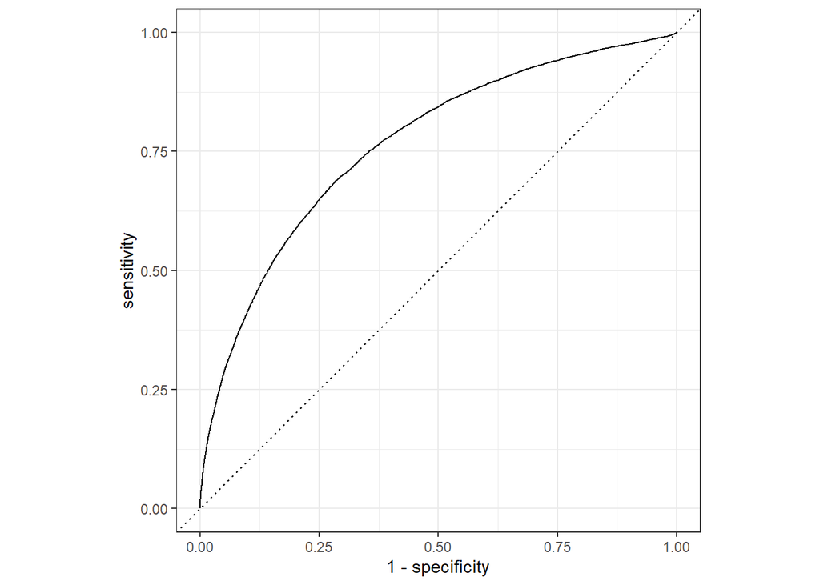

```r
flights_pred %>%
  roc_curve(truth = arr_delay, .pred_late) %>%
  autoplot()
```

#### ROC_AUC

```r
flights_pred %>%
  roc_auc(truth = arr_delay, .pred_late)
```

```
## # A tibble: 1 x 3
##   .metric .estimator .estimate
##   <chr>   <chr>          <dbl>
## 1 roc_auc binary         0.765
```

결과가 나쁘지 않습니다. 다음화에서는 **Evaluation**에 대해 더 깊이 다뤄보도록 하겠습니다.